# 2025-06-04_ARK_approved_access

Jess Vera

Start date: 2025-06-04  
Last updated: 2025-06-04 12:47:19.328276

# Setup

```r
# source rmarkdown_setup.R
source("~/Setup/rmarkdown_setup.R")

# Load libraries silently
suppressPackageStartupMessages({
  library(dplyr)
  library(stringr)
  library(ggplot2)
  library(lubridate)
  library(glue)
})
```

# Main

```bash
grep "accepted on" ../all_approved_access_requests.txt > ../all_accepted_dates.txt
```

```r
df <- read.delim("../all_accepted_dates.txt", header= FALSE, sep = " ")
df <- df[,c(1,ncol(df))]
colnames(df) <- c("V1", "approved_date")
df$approved_date <- str_remove_all(df$approved_date, "\\)|\\(|:")
df <- mutate(df, year = year(mdy(approved_date)),
             month_str = month(mdy(approved_date), label = TRUE, abbr = TRUE),
             month_int = month(mdy(approved_date)))
message(glue("There are {nrow(df)} total access requests that have been approved since the inception of the ARK Portal"))
```

```
## There are 142 total access requests that have been approved since the inception of the ARK Portal
```

```r
df$date <- paste(df$month_str, df$year)
df <- group_by(df, month_int, year, date) %>% tidyr::nest()
df$count <- unlist(purrr::map(df$data, nrow))
df <- arrange(df, year, month_int)
df$date <- forcats::fct_inorder(df$date)

my_kable_table(tail(select(df, date, count)), cap = "tail of the ARK Portal approved access requests summary df")
```

tail of the ARK Portal approved access requests summary df

| month_int | year | date | count |
| --- | --- | --- | --- |
| 12 | 2024 | Dec 2024 | 10 |
| 1 | 2025 | Jan 2025 | 7 |
| 2 | 2025 | Feb 2025 | 9 |
| 3 | 2025 | Mar 2025 | 15 |
| 4 | 2025 | Apr 2025 | 9 |
| 5 | 2025 | May 2025 | 15 |

```r
df$year <- as.character(df$year)
#yrcols <- c("grey85", "grey40", "black")
yrcols <- rev(pals::ocean.gray(n = length(unique(df$year))))
yrcols[1] <- "grey85"
names(yrcols) <- unique(df$year)

p <- ggplot(df, aes(x = date, y = count, fill = year)) +
       geom_col() + theme_minimal() +
       scale_fill_manual(values = yrcols) +
       theme(text = element_text(size = 8),
             axis.text.x = element_text(angle = 45, vjust = 1, hjust = 1, size = 6),
             title = element_text(size = 10)) +
       ggtitle("ARK Portal Approved Access Requests")

w = nrow(df)*50
fid <- "ARK Portal Approved Access Requests.png"
png(fid, width = w, height = 750, res = 250)
print(p)
invisible(dev.off())
```

# Results

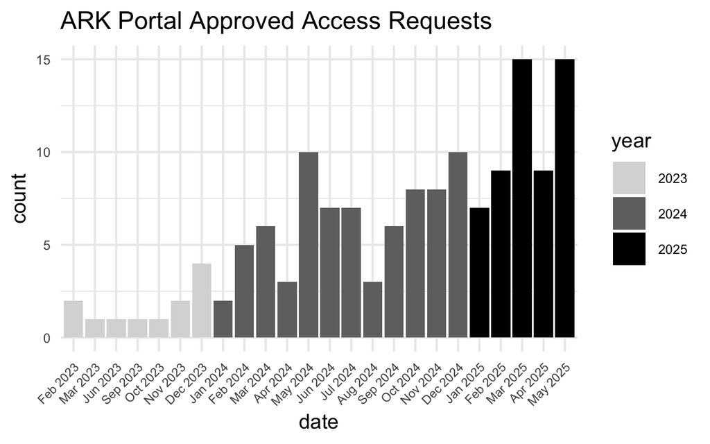

```r
knitr::include_graphics(fid)
```

# Session Details

```r
#Print out session info
R.utils::System$getHostname();
```

```
nodename
```

“w255.local”

R version 4.3.3 (2024-02-29) Platform: aarch64-apple-darwin20 (64-bit) Running under: macOS Sonoma 14.7.3

Matrix products: default BLAS: /Library/Frameworks/R.framework/Versions/4.3-arm64/Resources/lib/libRblas.0.dylib LAPACK: /Library/Frameworks/R.framework/Versions/4.3-arm64/Resources/lib/libRlapack.dylib; LAPACK version 3.11.0

locale: [1] en_US.UTF-8/en_US.UTF-8/en_US.UTF-8/C/en_US.UTF-8/en_US.UTF-8

time zone: America/Chicago tzcode source: internal

attached base packages: [1] stats graphics grDevices utils datasets methods base

other attached packages: [1] glue_1.8.0 lubridate_1.9.4 ggplot2_3.5.1 stringr_1.5.1  
[5] dplyr_1.1.4

loaded via a namespace (and not attached): [1] sass_0.4.9 generics_0.1.3 tidyr_1.3.1 xml2_1.3.6  
[5] stringi_1.8.4 digest_0.6.37 magrittr_2.0.3 evaluate_1.0.1  
[9] grid_4.3.3 timechange_0.3.0 fastmap_1.2.0 maps_3.4.2.1  
[13] R.oo_1.27.0 jsonlite_1.8.9 R.utils_2.12.3 pals_1.10  
[17] httr_1.4.7 purrr_1.0.2 viridisLite_0.4.2 scales_1.3.0  
[21] jquerylib_0.1.4 cli_3.6.3 rlang_1.1.4 R.methodsS3_1.8.2 [25] munsell_0.5.1 withr_3.0.2 cachem_1.1.0 yaml_2.3.10  
[29] tools_4.3.3 colorspace_2.1-1 forcats_1.0.0 kableExtra_1.4.0 [33] png_0.1-8 vctrs_0.6.5 mapproj_1.2.11 R6_2.5.1  
[37] lifecycle_1.0.4 pkgconfig_2.0.3 pillar_1.10.0 bslib_0.8.0  
[41] gtable_0.3.6 systemfonts_1.1.0 xfun_0.49 tibble_3.2.1  
[45] tidyselect_1.2.1 rstudioapi_0.17.1 knitr_1.49 dichromat_2.0-0.1 [49] farver_2.1.2 htmltools_0.5.8.1 rmarkdown_2.29 svglite_2.1.3  
[53] labeling_0.4.3 compiler_4.3.3